# Coordination des Centres de Prévention et de Santé de Guyane

# 2 Nombre de fiches créées dans SISv2

|  | 2021 |  |  |  |  |  |  |  |  |  |  | 2022 | Total |
| --- | --- | --- | --- | --- | --- | --- | --- | --- | --- | --- | --- | --- | --- |
|  | févr. | mars | avr. | mai | juin | juil. | août | sept. | oct. | nov. | déc. | janv. |  |
| Pré-consultation | 6171 | 9211 | 8500 | 8476 | 9050 | 7953 | 7198 | 8611 | 8214 | 8026 | 6942 | 8929 | 97281 |
| Consultation | 4791 | 6389 | 5465 | 5341 | 5773 | 4826 | 4678 | 6361 | 6025 | 6318 | 5343 | 7456 | 68766 |
| Vaccination | 668 | 615 | 572 | 426 | 490 | 647 | 468 | 594 | 770 | 865 | 816 | 852 | 7783 |
| Consultation obstétrique | 327 | 360 | 339 | 306 | 347 | 286 | 277 | 323 | 305 | 311 | 240 | 265 | 3686 |
| Mise en observation | 192 | 216 | 258 | 258 | 282 | 264 | 250 | 245 | 323 | 291 | 316 | 306 | 3201 |
| Echographie | 126 | 143 | 123 | 184 | 188 | 104 | 116 | 113 | 100 | 138 | 90 | 158 | 1583 |
| Accouchement | 10 | 6 | 9 | 7 | 12 | 11 | 7 | 5 | 1 | 6 | 1 | 4 | 79 |
| Total | 12285 | 16940 | 15266 | 14998 | 16142 | 14091 | 12994 | 16252 | 15738 | 15955 | 13748 | 17970 | 182379 |

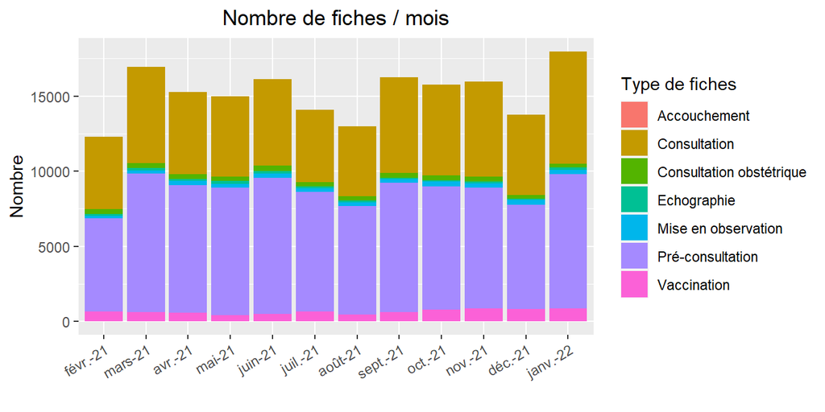

# 3 File active quotienne

Le tableau ci-dessous donne la moyenne du nombre de patients accueillis dans les centres pour chaque jour de la semaine, sur les 12 derniers mois.

|  | 2021 |  |  |  |  |  |  |  |  |  |  | 2022 | Moyenne |
| --- | --- | --- | --- | --- | --- | --- | --- | --- | --- | --- | --- | --- | --- |
|  | févr. | mars | avr. | mai | juin | juil. | août | sept. | oct. | nov. | déc. | janv. |  |
| Lundi | 359 | 459 | 346 | 369 | 466 | 367 | 355 | 499 | 502 | 398 | 352 | 563 | 420 |
| Mardi | 305 | 401 | 430 | 463 | 435 | 396 | 356 | 468 | 463 | 425 | 385 | 519 | 419 |
| Mercredi | 319 | 421 | 468 | 504 | 517 | 336 | 368 | 409 | 456 | 439 | 357 | 523 | 426 |
| Jeudi | 412 | 424 | 416 | 359 | 362 | 390 | 365 | 447 | 434 | 356 | 349 | 523 | 403 |
| Vendredi | 326 | 361 | 351 | 399 | 408 | 378 | 319 | 431 | 383 | 408 | 286 | 439 | 372 |
| Samedi | 62 | 64 | 64 | 68 | 66 | 72 | 55 | 76 | 73 | 66 | 63 | 92 | 69 |
| Dimanche | 44 | 50 | 52 | 65 | 55 | 56 | 51 | 56 | 60 | 54 | 52 | 66 | 55 |

# 4 Consultations de médecine générale

Sont prises en comptes toutes les fiches *Consultation* et *Consultation obstétricale* pour lesquelles le type de consultation renseignée est “**A - Consultation de médecine générale (Examen clinique / consultation médicale)“**

|  | Janvier |  |  |  |  |  |  |  |  |  |  |  |  |  |  |  |  |  |
| --- | --- | --- | --- | --- | --- | --- | --- | --- | --- | --- | --- | --- | --- | --- | --- | --- | --- | --- |
|  | Maripasoula | Saint Georges | Grand Santi | Apatou | Papaichton | Talhuen | Antecum Pata | Cacao | Regina | Saul | Camopi | Trois Sauts | Kaw | Iracoubo | Javouhey | Awala | Zones hors CDPS | Total |
| Médecine générale | 1011 | 976 | 1357 | 721 | 493 | 164 | 41 | 205 | 127 | 27 | 483 | 275 | 16 | 313 | 250 | 178 | 69 | 6706 |

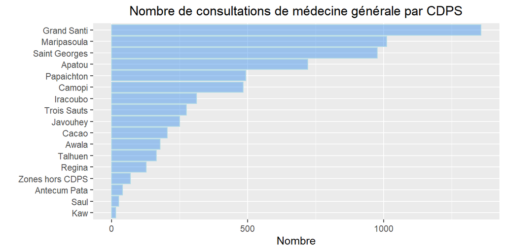

# 5 Gynécologie - Obstétrique

## 5.1 File active des grossesse

### 5.1.1 Mensuelle

La file active contient toutes les patientes ayant eu au moins une fois une fiche *“Consultation obstétricale”* dans le mois. Il est important d’utiliser la fiche *“Consultation obstétricale”* dès lors qu’on prend en charge une femme enceinte.

|  | 2021 |  |  |  |  |  |  |  |  |  |  | 2022 | Moyenne |
| --- | --- | --- | --- | --- | --- | --- | --- | --- | --- | --- | --- | --- | --- |
|  | févr. | mars | avr. | mai | juin | juil. | août | sept. | oct. | nov. | déc. | janv. |  |
| File active | 273 | 284 | 263 | 249 | 274 | 221 | 208 | 253 | 250 | 244 | 207 | 218 | 245 |

### 5.1.2 Sur les 12 derniers mois

- 1063 femmes enceintes ont été suivies sur les 12 derniers mois.

## 5.2 Echographies

### 5.2.1 Par CDPS

|  | Janvier |  |  |  |  |  |  |  |  |  |  |  |  |  |  |  |  |  |
| --- | --- | --- | --- | --- | --- | --- | --- | --- | --- | --- | --- | --- | --- | --- | --- | --- | --- | --- |
|  | Maripasoula | Saint Georges | Grand Santi | Apatou | Papaichton | Talhuen | Antecum Pata | Cacao | Regina | Saul | Camopi | Trois Sauts | Kaw | Iracoubo | Javouhey | Awala | Zones hors CDPS | Total |
| Sage-femme | 20 |  | 63 |  |  |  |  |  |  |  |  |  |  |  |  |  |  | 83 |
| Gynécologue |  | 29 | 7 |  |  |  |  |  |  |  |  |  |  |  |  |  |  | 36 |
| Médecin |  | 2 |  |  |  |  |  |  |  |  |  |  |  |  |  |  |  | 2 |
| Total | 20 | 31 | 70 |  |  |  |  |  |  |  |  |  |  |  |  |  |  | 121 |

### 5.2.2 Sur les 12 derniers mois par professionnel

|  | 2021 |  |  |  |  |  |  |  |  |  |  | 2022 | Total |
| --- | --- | --- | --- | --- | --- | --- | --- | --- | --- | --- | --- | --- | --- |
|  | févr. | mars | avr. | mai | juin | juil. | août | sept. | oct. | nov. | déc. | janv. |  |
| Sage-femme | 120 | 107 | 73 | 154 | 177 | 82 | 95 | 88 | 80 | 110 | 73 | 83 | 1242 |
| Gynécologue | 2 | 33 | 44 | 23 | 8 | 20 | 20 | 23 | 16 | 26 | 13 | 36 | 264 |
| Médecin |  |  |  |  |  |  |  |  |  | 1 |  | 2 | 3 |
| Total | 122 | 140 | 117 | 177 | 185 | 102 | 115 | 111 | 96 | 137 | 86 | 121 | 1509 |

## 5.3 Consultations sages-femmes

**Remarque** : dans SISv2, l’activité des sages-femmes se mesure par l’ensemble des fiches *“Consultation”*, *“Consultation obsté”* et *“Echographie”* où le *“type de consultation”* renseigné correspond aux sages-femmes.

|  | Janvier |  |  |  |  |  |  |  |  |  |  |  |  |  |  |  |  |  |
| --- | --- | --- | --- | --- | --- | --- | --- | --- | --- | --- | --- | --- | --- | --- | --- | --- | --- | --- |
|  | Maripasoula | Saint Georges | Grand Santi | Apatou | Papaichton | Talhuen | Antecum Pata | Cacao | Regina | Saul | Camopi | Trois Sauts | Kaw | Iracoubo | Javouhey | Awala | Zones hors CDPS | Total |
| Consultation | 119 | 58 | 103 | 3 | 18 |  | 17 | 2 |  |  | 1 | 1 |  |  |  |  |  | 322 |
| Consultation obstétrique | 55 | 41 | 96 |  | 22 |  |  |  |  |  | 19 | 4 |  |  |  |  |  | 237 |
| Echographie | 20 |  | 64 |  |  |  |  |  |  |  |  |  |  |  |  |  |  | 84 |
| Total | 194 | 99 | 263 | 3 | 40 |  | 17 | 2 |  |  | 20 | 5 |  |  |  |  |  | 643 |

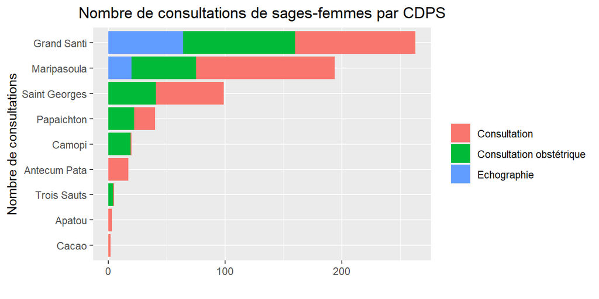

## 5.4 Liste des diagnostics renseignés lors des consultations obstétriques sages-femmes

|  | Janvier |  |  |  |  |  |  |  |  |  |  |  |  |  |  |  |  |  |
| --- | --- | --- | --- | --- | --- | --- | --- | --- | --- | --- | --- | --- | --- | --- | --- | --- | --- | --- |
|  | Maripasoula | Saint Georges | Grand Santi | Apatou | Papaichton | Talhuen | Antecum Pata | Cacao | Regina | Saul | Camopi | Trois Sauts | Kaw | Iracoubo | Javouhey | Awala | Zones hors CDPS | Total |
| Surveillance grossesse à risque | 31 | 3 | 84 |  | 11 |  |  |  |  |  |  |  |  |  |  |  |  | 129 |
| Surveillance grossesse normale | 21 | 36 | 6 |  | 11 |  |  |  |  |  | 19 | 4 |  |  |  |  |  | 97 |
| Infection respiratoire à Coronavirus (patient testé, résultat positif) |  |  | 4 |  |  |  |  |  |  |  |  |  |  |  |  |  |  | 4 |
| Diabete sucre au cours de la grossesse |  | 1 |  |  |  |  |  |  |  |  |  |  |  |  |  |  |  | 1 |
| Douleurs abdominales autres et non précisées (abdomen sensible - colique) |  |  | 1 |  |  |  |  |  |  |  |  |  |  |  |  |  |  | 1 |
| Examen gynecologique (de routine) sans précision | 1 |  |  |  |  |  |  |  |  |  |  |  |  |  |  |  |  | 1 |
| Grossesse multiple | 1 |  |  |  |  |  |  |  |  |  |  |  |  |  |  |  |  | 1 |
| Infections de l'appareil génito-urinaire au cours de la grossesse |  |  | 1 |  |  |  |  |  |  |  |  |  |  |  |  |  |  | 1 |
| Mycoses - sans precision |  | 1 |  |  |  |  |  |  |  |  |  |  |  |  |  |  |  | 1 |
| Rupture prématurée des membranes | 1 |  |  |  |  |  |  |  |  |  |  |  |  |  |  |  |  | 1 |
| Total | 55 | 41 | 96 |  | 22 |  |  |  |  |  | 19 | 4 |  |  |  |  |  | 237 |

## 5.5 Liste des diagnostics renseignés lors des consultations sages-femmes hors obstétrique

|  | Janvier |  |  |  |  |  |  |  |  |  |  |  |  |  |  |  |  |  |
| --- | --- | --- | --- | --- | --- | --- | --- | --- | --- | --- | --- | --- | --- | --- | --- | --- | --- | --- |
|  | Maripasoula | Saint Georges | Grand Santi | Apatou | Papaichton | Talhuen | Antecum Pata | Cacao | Regina | Saul | Camopi | Trois Sauts | Kaw | Iracoubo | Javouhey | Awala | Zones hors CDPS | Total |
| Examen gynecologique (de routine) sans précision | 48 | 18 | 24 |  | 8 |  | 17 | 1 |  |  |  |  |  |  |  |  |  | 116 |
| Interruption Volontaire de Grossesse (IVG - Avortement - MOTIF PERSONNEL) | 19 | 12 | 1 |  |  |  |  |  |  |  |  |  |  |  |  |  |  | 32 |
| Surveillance grossesse à risque | 1 | 1 | 23 |  | 3 |  |  |  |  |  |  |  |  |  |  |  |  | 28 |
| Surveillance grossesse normale | 19 | 2 | 1 |  | 5 |  |  |  |  |  |  | 1 |  |  |  |  |  | 28 |
| Examen et test de grossesse |  | 5 | 9 |  |  |  |  | 1 |  |  |  |  |  |  |  |  |  | 15 |
| Conseils et avis généraux concernant la contraception |  | 4 | 6 |  |  |  |  |  |  |  |  |  |  |  |  |  |  | 10 |
| Soins et examens du post-partum | 2 |  | 7 |  |  |  |  |  |  |  |  |  |  |  |  |  |  | 9 |
| Avortement spontane involontaire (fausse couche) | 2 | 1 | 4 |  |  |  |  |  |  |  |  |  |  |  |  |  |  | 7 |
| Menorragie - polymenorrhee et metrorragie | 1 | 2 | 2 |  |  |  |  |  |  |  |  |  |  |  |  |  |  | 5 |
| Mise en place ou surveillance d'un dispositif contraceptif intra utérin (DIU - stérilet) |  | 2 | 3 |  |  |  |  |  |  |  |  |  |  |  |  |  |  | 5 |
| Prescription de pilule contraceptive |  |  | 5 |  |  |  |  |  |  |  |  |  |  |  |  |  |  | 5 |
| Changement ou ablation d’un dispositif contraceptif sous-cutané (implant) |  | 3 | 1 |  |  |  |  |  |  |  |  |  |  |  |  |  |  | 4 |
| Douleurs et autres affections des organes genitaux et de la femme et du cycle menstruel |  |  | 4 |  |  |  |  |  |  |  |  |  |  |  |  |  |  | 4 |
| Hypertension artérielle (HTA) primitive | 3 |  |  |  |  |  |  |  |  |  |  |  |  |  |  |  |  | 3 |
| Infection respiratoire à Coronavirus (patient testé, résultat positif) | 2 |  |  | 1 |  |  |  |  |  |  |  |  |  |  |  |  |  | 3 |
| Mise en place ou surveillance d'un dispositif contraceptif sous-cutané (implant) | 1 | 2 |  |  |  |  |  |  |  |  |  |  |  |  |  |  |  | 3 |
| Contrôle de routine au cours du post-partum (surveillance) |  |  | 2 |  |  |  |  |  |  |  |  |  |  |  |  |  |  | 2 |
| Examen renouvellement d'ordonnance (sauf contraceptif) | 2 |  |  |  |  |  |  |  |  |  |  |  |  |  |  |  |  | 2 |
| Grippe - virus non identifie |  | 1 |  |  |  |  |  |  |  |  | 1 |  |  |  |  |  |  | 2 |
| Hémorragie du début de grossesse sans précision | 1 |  | 1 |  |  |  |  |  |  |  |  |  |  |  |  |  |  | 2 |
| Affection de la peau et du tissu cellulaire sous-cutanée - sans precision | 1 |  |  |  |  |  |  |  |  |  |  |  |  |  |  |  |  | 1 |
| Affection inflammatoire pelvienne chez la femme - sans précision |  |  | 1 |  |  |  |  |  |  |  |  |  |  |  |  |  |  | 1 |
| Amenorrhee secondaire |  |  | 1 |  |  |  |  |  |  |  |  |  |  |  |  |  |  | 1 |
| Asthénie (Malaise et fatigue) | 1 |  |  |  |  |  |  |  |  |  |  |  |  |  |  |  |  | 1 |
| Bronchite aigue |  |  |  |  | 1 |  |  |  |  |  |  |  |  |  |  |  |  | 1 |
| Causes inconnues et non precisees de morbidité | 1 |  |  |  |  |  |  |  |  |  |  |  |  |  |  |  |  | 1 |
| Changement ou ablation d'un dispositif contraceptif intra utérin (DIU - stérilet) |  | 1 |  |  |  |  |  |  |  |  |  |  |  |  |  |  |  | 1 |
| Chute sans precision |  |  | 1 |  |  |  |  |  |  |  |  |  |  |  |  |  |  | 1 |
| Cystite |  |  |  |  | 1 |  |  |  |  |  |  |  |  |  |  |  |  | 1 |
| Delivrance d'un certificat medical | 1 |  |  |  |  |  |  |  |  |  |  |  |  |  |  |  |  | 1 |
| Dermatophytose (teigne etc ) | 1 |  |  |  |  |  |  |  |  |  |  |  |  |  |  |  |  | 1 |
| Diabete Non Insulino-Dependant- de type 2 | 1 |  |  |  |  |  |  |  |  |  |  |  |  |  |  |  |  | 1 |
| Diabète sucré survenant au cours de la grossesse |  |  | 1 |  |  |  |  |  |  |  |  |  |  |  |  |  |  | 1 |
| Diarrhee et gastro-enterite d'origine presumee infectieuse | 1 |  |  |  |  |  |  |  |  |  |  |  |  |  |  |  |  | 1 |
| Douleur abdominale et pelvienne |  | 1 |  |  |  |  |  |  |  |  |  |  |  |  |  |  |  | 1 |
| Douleur au niveau d'un membre | 1 |  |  |  |  |  |  |  |  |  |  |  |  |  |  |  |  | 1 |
| Douleur epigastrique (localisée à la partie supérieure de l'abdomen) | 1 |  |  |  |  |  |  |  |  |  |  |  |  |  |  |  |  | 1 |
| Douleur sans précision (douleurs généralisées) |  |  | 1 |  |  |  |  |  |  |  |  |  |  |  |  |  |  | 1 |
| Examen laboratoire | 1 |  |  |  |  |  |  |  |  |  |  |  |  |  |  |  |  | 1 |
| Examen medical general | 1 |  |  |  |  |  |  |  |  |  |  |  |  |  |  |  |  | 1 |
| Fievre d'origine inconnue |  |  |  | 1 |  |  |  |  |  |  |  |  |  |  |  |  |  | 1 |
| Grossesse constatee fortuitement |  | 1 |  |  |  |  |  |  |  |  |  |  |  |  |  |  |  | 1 |
| Grossesse extra-uterine |  |  | 1 |  |  |  |  |  |  |  |  |  |  |  |  |  |  | 1 |
| Incontinence urinaire - sans precision |  |  | 1 |  |  |  |  |  |  |  |  |  |  |  |  |  |  | 1 |
| Infection respiratoire à Coronavirus (patient testé en attente de résultats) | 1 |  |  |  |  |  |  |  |  |  |  |  |  |  |  |  |  | 1 |
| Injection contraceptive (DEPO) | 1 |  |  |  |  |  |  |  |  |  |  |  |  |  |  |  |  | 1 |
| Irrégularités menstruelles sans précision |  |  | 1 |  |  |  |  |  |  |  |  |  |  |  |  |  |  | 1 |
| Kyste sébacé (canal - glande) | 1 |  |  |  |  |  |  |  |  |  |  |  |  |  |  |  |  | 1 |
| Plaie ouverte de la jambe |  |  |  | 1 |  |  |  |  |  |  |  |  |  |  |  |  |  | 1 |
| Prurit | 1 |  |  |  |  |  |  |  |  |  |  |  |  |  |  |  |  | 1 |
| Stomatites et affections apparentees | 1 |  |  |  |  |  |  |  |  |  |  |  |  |  |  |  |  | 1 |
| Surveillance de contraceptifs (Pilules/DEPO - hors renouvellement de traitement ou d’ordonnance) |  |  | 1 |  |  |  |  |  |  |  |  |  |  |  |  |  |  | 1 |
| Tendinite calcifiante de l'epaule | 1 |  |  |  |  |  |  |  |  |  |  |  |  |  |  |  |  | 1 |
| Toux | 1 |  |  |  |  |  |  |  |  |  |  |  |  |  |  |  |  | 1 |
| Troubles de la menopause et du climatere feminin |  | 1 |  |  |  |  |  |  |  |  |  |  |  |  |  |  |  | 1 |
| Vomissements de la grossesse - sans precision |  | 1 |  |  |  |  |  |  |  |  |  |  |  |  |  |  |  | 1 |
| Vomissements incoercibles au cours de la grossesse |  |  | 1 |  |  |  |  |  |  |  |  |  |  |  |  |  |  | 1 |
| Total | 119 | 58 | 103 | 3 | 18 |  | 17 | 2 |  |  | 1 | 1 |  |  |  |  |  | 322 |

## 5.6 Accouchements hors milieu hospitalier

**Remarque** : tout accouchement ayant lieu au CDPS doit faire l’objet d’une fiche *Accouchement* dans SISv2. Compte tenu de la charge de travail administrative qu’un accouchement représente, il est demandé, dans SISv2, de ne remplir que les 3 premiers champs de la fiche :

- Centre de santé
- Date de l’accouchement
- Lieu de l’accouchement

|  | Janvier |  |  |  |  |  |  |  |  |  |  |  |  |  |  |  |  |  |
| --- | --- | --- | --- | --- | --- | --- | --- | --- | --- | --- | --- | --- | --- | --- | --- | --- | --- | --- |
|  | Maripasoula | Saint Georges | Grand Santi | Apatou | Papaichton | Talhuen | Antecum Pata | Cacao | Regina | Saul | Camopi | Trois Sauts | Kaw | Iracoubo | Javouhey | Awala | Zones hors CDPS | Total |
| Centre délocalisé de prévention et de soin | 1 | 2 |  |  | 1 |  |  |  |  |  |  |  |  |  |  |  |  | 4 |
| Total | 1 | 2 |  |  | 1 |  |  |  |  |  |  |  |  |  |  |  |  | 4 |

# 6 Consultation / Préconsultations par IDE et AS

|  | Janvier |  |  |  |  |  |  |  |  |  |  |  |  |  |  |  |  |  |
| --- | --- | --- | --- | --- | --- | --- | --- | --- | --- | --- | --- | --- | --- | --- | --- | --- | --- | --- |
|  | Maripasoula | Saint Georges | Grand Santi | Apatou | Papaichton | Talhuen | Antecum Pata | Cacao | Regina | Saul | Camopi | Trois Sauts | Kaw | Iracoubo | Javouhey | Awala | Zones hors CDPS | Total |
| Pré-consultation | 1929 | 648 | 1548 | 1046 | 719 | 341 | 232 | 226 | 1 | 88 | 529 | 344 | 31 | 381 | 405 | 457 | 4 | 8929 |
| Consult. paramédicale par IDE ou AS | 21 |  |  |  |  | 18 | 40 | 15 |  | 1 |  | 26 |  |  |  |  |  | 121 |
| Addictologie par IDE |  |  |  | 1 |  |  |  |  |  |  |  |  |  |  |  |  |  | 1 |
| Total | 1950 | 648 | 1548 | 1047 | 719 | 359 | 272 | 241 | 1 | 89 | 529 | 370 | 31 | 381 | 405 | 457 | 4 | 9051 |

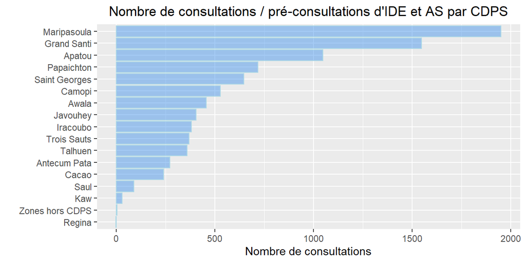

# 7 Consultations spécialisées

Pour la gynécologie-obstétrique, sont exclues les échographies (voir chapitre *Gynécologie-Obstétrique* pour ces données).

## 7.1 Par CDPS

|  | Janvier |  |  |  |  |  |  |  |  |  |  |  |  |  |  |  |  |  |
| --- | --- | --- | --- | --- | --- | --- | --- | --- | --- | --- | --- | --- | --- | --- | --- | --- | --- | --- |
|  | Maripasoula | Saint Georges | Grand Santi | Apatou | Papaichton | Talhuen | Antecum Pata | Cacao | Regina | Saul | Camopi | Trois Sauts | Kaw | Iracoubo | Javouhey | Awala | Zones hors CDPS | Total |
| Spécialiste en Pédiatrie | 14 | 37 | 32 | 4 | 20 |  |  |  | 6 |  |  |  |  |  |  | 3 |  | 116 |
| Spécialiste en Dermatologie | 18 |  |  |  |  | 15 |  | 1 |  |  |  |  | 1 |  |  |  |  | 35 |
| Spécialiste en Hépatologie | 17 |  |  |  | 2 | 2 |  |  |  |  |  |  |  |  |  |  |  | 21 |
| Gynécologie par un(e) gynécologue |  | 10 | 10 |  |  |  |  |  |  |  |  |  |  |  |  |  |  | 20 |
| Spécialiste en Infectiologie | 10 | 3 |  |  | 3 |  |  |  |  |  |  |  |  |  |  |  |  | 16 |
| Psychiatrie (psychiatre ou autre) | 1 |  | 12 |  |  |  |  |  |  |  |  |  |  |  |  |  |  | 13 |
| Total | 60 | 50 | 54 | 4 | 25 | 17 |  | 1 | 6 |  |  |  | 1 |  |  | 3 |  | 221 |

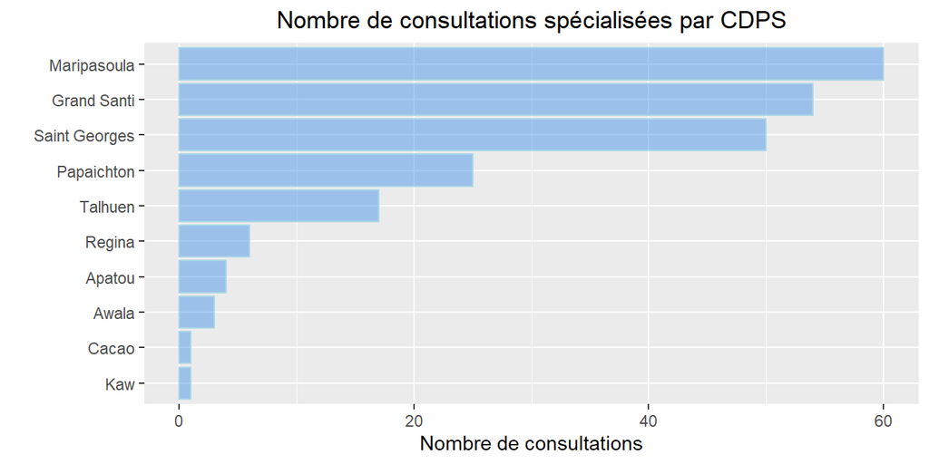

## 7.2 Sur les 12 derniers mois

|  | 2021 |  |  |  |  |  |  |  |  |  |  | 2022 | Total |
| --- | --- | --- | --- | --- | --- | --- | --- | --- | --- | --- | --- | --- | --- |
|  | févr. | mars | avr. | mai | juin | juil. | août | sept. | oct. | nov. | déc. | janv. |  |
| Spécialiste en Pédiatrie | 23 | 50 | 57 | 48 | 1 | 73 | 40 | 111 | 38 | 29 | 61 | 116 | 647 |
| Spécialiste en Infectiologie | 60 | 45 | 67 | 28 | 62 | 58 | 10 | 29 | 24 | 25 | 25 | 16 | 449 |
| Gynécologie par un(e) gynécologue | 22 | 23 | 17 | 12 | 25 | 9 | 16 | 25 | 14 | 101 | 23 | 20 | 307 |
| Spécialiste en Dermatologie |  | 23 | 27 | 42 | 42 | 27 | 23 | 18 |  | 27 | 29 | 35 | 293 |
| Psychiatrie (psychiatre ou autre) |  | 4 | 5 | 7 | 15 |  | 18 | 1 | 15 | 9 | 6 | 13 | 93 |
| Spécialiste en Diabétologie |  |  |  |  |  | 13 | 5 |  | 10 | 12 |  |  | 40 |
| Spécialiste en Urologie | 8 |  |  |  |  | 1 | 5 |  |  | 19 |  |  | 33 |
| Spécialiste en Hépatologie | 1 |  |  |  | 3 |  | 1 |  |  |  |  | 21 | 26 |
| Spécialiste en Orthoptie |  | 17 |  |  |  |  |  |  | 1 |  |  |  | 18 |
| Spécialiste en Ophtalmologie |  | 1 |  |  |  |  |  |  |  |  |  |  | 1 |
| Spécialiste en Orthopédie |  |  |  |  |  |  |  |  |  | 1 |  |  | 1 |
| Total | 114 | 163 | 173 | 137 | 148 | 181 | 118 | 184 | 102 | 223 | 144 | 221 | 1908 |

# 8 Mises en observation

|  | Janvier |  |  |  |  |  |  |  |  |  |  |  |  |  |  |  |  |  |
| --- | --- | --- | --- | --- | --- | --- | --- | --- | --- | --- | --- | --- | --- | --- | --- | --- | --- | --- |
|  | Maripasoula | Saint Georges | Grand Santi | Apatou | Papaichton | Talhuen | Antecum Pata | Cacao | Regina | Saul | Camopi | Trois Sauts | Kaw | Iracoubo | Javouhey | Awala | Zones hors CDPS | Total |
| Mise en observation | 67 | 122 | 52 | 28 | 10 | 6 | 2 |  | 2 |  | 10 | 7 |  |  |  |  |  | 306 |

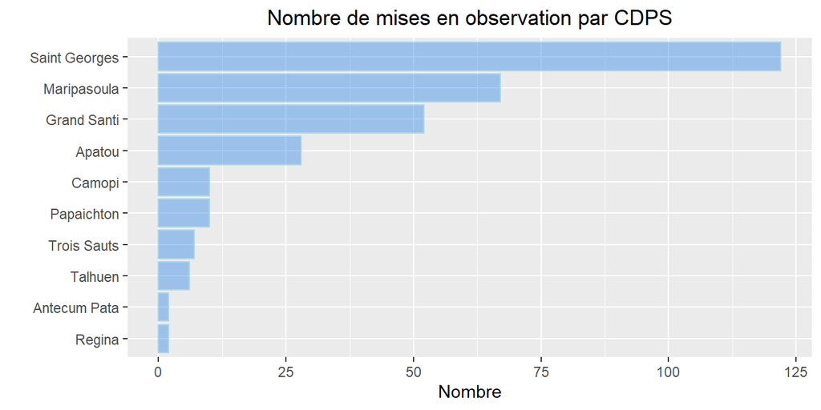

# 9 Transferts urgents

|  | Janvier |  |  |  |  |  |  |  |  |  |  |  |  |  |  |  |  |  |
| --- | --- | --- | --- | --- | --- | --- | --- | --- | --- | --- | --- | --- | --- | --- | --- | --- | --- | --- |
|  | Maripasoula | Saint Georges | Grand Santi | Apatou | Papaichton | Talhuen | Antecum Pata | Cacao | Regina | Saul | Camopi | Trois Sauts | Kaw | Iracoubo | Javouhey | Awala | Zones hors CDPS | Total |
| Hélicoptère | 14 | 2 | 17 |  | 1 |  |  |  | 1 |  | 4 | 1 |  |  |  |  |  | 40 |
| Route | 2 | 25 |  | 7 |  |  |  |  | 1 |  |  |  |  |  |  |  |  | 35 |
| Avion | 2 |  | 3 |  |  |  |  |  |  |  | 1 |  |  |  |  |  |  | 6 |
| Pirogue |  |  | 2 |  |  |  |  |  |  |  |  |  |  |  |  |  |  | 2 |
| Total | 18 | 27 | 22 | 7 | 1 |  |  |  | 2 |  | 5 | 1 |  |  |  |  |  | 83 |

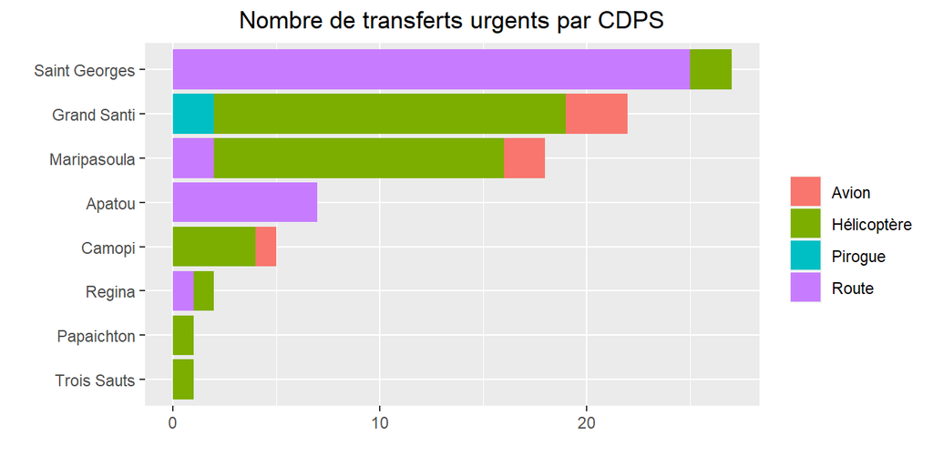

# 10 Décès

Le comptage des décès se base sur la date de décès renseignée dans la fiche d’identité du patient. Il est donc important de la mettre à jour si vous avez connaissance d’un décès au CDPS ou suite à un transfert vers l’hôpital.

|  | 2021 |  |  |  |  |  |  |  |  |  |  | 2022 | Total |
| --- | --- | --- | --- | --- | --- | --- | --- | --- | --- | --- | --- | --- | --- |
|  | févr. | mars | avr. | mai | juin | juil. | août | sept. | oct. | nov. | déc. | janv. |  |
| Grand Santi | 1 |  | 3 | 3 | 1 | 2 | 2 | 2 | 3 | 2 | 1 | 1 | 21 |
| Saint Georges | 1 | 1 | 2 | 1 |  | 1 | 2 | 2 | 2 | 4 | 1 |  | 17 |
| Maripasoula | 1 |  |  | 3 |  |  | 1 |  |  | 2 | 1 | 1 | 9 |
| Iracoubo | 1 |  | 1 |  | 1 | 1 |  | 2 |  | 1 |  |  | 7 |
| Papaichton |  |  |  |  |  |  | 2 |  |  | 1 | 1 | 1 | 5 |
| Apatou |  |  |  |  | 1 |  |  | 1 |  | 1 |  |  | 3 |
| Awala | 2 |  |  |  |  |  |  |  |  |  | 1 |  | 3 |
| Cacao |  |  |  |  |  |  | 1 |  |  |  | 1 | 1 | 3 |
| Camopi |  |  |  |  |  |  | 1 |  | 1 |  | 1 |  | 3 |
| Regina |  |  | 1 |  |  | 1 |  | 1 |  |  |  |  | 3 |
| Antecum Pata |  |  |  |  |  |  |  |  | 1 |  |  |  | 1 |
| Javouhey |  |  |  |  |  |  |  | 1 |  |  |  |  | 1 |
| Total | 6 | 1 | 7 | 7 | 3 | 5 | 9 | 9 | 7 | 11 | 7 | 4 | 76 |

# 11 Famille de diagnostics

## 11.1 Par CDPS

|  | Janvier |  |  |  |  |  |  |  |  |  |  |  |  |  |  |  |  |  |
| --- | --- | --- | --- | --- | --- | --- | --- | --- | --- | --- | --- | --- | --- | --- | --- | --- | --- | --- |
|  | Maripasoula | Saint Georges | Grand Santi | Apatou | Papaichton | Talhuen | Antecum Pata | Cacao | Regina | Saul | Camopi | Trois Sauts | Kaw | Iracoubo | Javouhey | Awala | Zones hors CDPS | Total |
| MALADIES DE L'APPAREIL RESPIRATOIRES | 227 | 388 | 566 | 218 | 176 | 53 | 41 | 39 | 49 | 2 | 221 | 202 | 4 | 113 | 52 | 60 | 44 | 2455 |
| EXAMENS GENERAUX | 161 | 141 | 193 | 154 | 80 | 13 | 5 | 74 | 40 | 16 | 83 | 21 | 9 | 46 | 54 | 28 | 4 | 1122 |
| SYMPTOMES, SYNDROME ET ETATS DE MORBIDITES MAL DEFINIS | 225 | 203 | 156 | 121 | 66 | 51 | 15 | 17 | 10 |  | 43 | 5 |  | 28 | 33 | 31 | 1 | 1005 |
| OBSTETRIQUE | 167 | 135 | 216 | 18 | 50 | 4 | 20 | 7 | 8 | 1 | 56 | 20 |  | 7 | 2 | 1 | 2 | 714 |
| MALADIES INFECTIEUSES ET PARASITAIRES | 128 | 59 | 77 | 32 | 25 | 20 | 2 | 16 | 5 | 1 | 29 | 25 | 3 | 26 | 23 | 21 | 5 | 497 |
| RHUMATOLOGIE | 60 | 35 | 57 | 34 | 25 | 21 | 8 | 6 | 3 | 1 | 18 | 8 |  | 14 | 20 | 9 | 2 | 321 |
| LESIONS TRAUMATIQUES EMPOISONNEMENT ET AUTRES CONSEQUENCES DE CAUSES EXTERNE | 57 | 66 | 42 | 31 | 36 | 5 | 1 | 2 | 1 |  | 22 | 9 |  | 13 | 8 | 2 | 4 | 299 |
| MALADIES DE L'APPAREIL CARDIO-VASCULAIRE | 52 | 36 | 77 | 26 | 27 | 2 |  | 17 | 7 | 2 |  | 1 |  | 3 | 5 | 1 |  | 256 |
| DERMATOLOGIE | 55 | 23 | 42 | 20 | 20 | 18 |  | 16 | 2 |  | 12 | 4 |  | 13 | 15 | 7 | 2 | 249 |
| MALADIES ENDOCRINO-METABOLIQUE | 40 | 44 | 40 | 9 | 7 | 6 | 2 | 19 | 6 | 3 |  |  | 1 | 3 | 3 | 2 | 1 | 186 |
| ORL | 13 | 37 | 37 | 13 | 8 | 4 | 2 | 2 | 3 | 1 | 8 | 2 |  | 11 | 6 | 3 | 2 | 152 |
| MALADIES DE L'APPAREIL DIGESTIF | 37 | 17 | 20 | 23 | 10 | 4 | 1 | 3 | 2 |  | 8 | 8 |  | 7 | 8 | 3 |  | 151 |
| NEUROLOGIE | 32 | 30 | 33 | 15 | 4 | 4 |  | 1 | 1 |  | 1 | 3 |  | 5 | 7 | 3 | 1 | 140 |
| NEPHROLOGIE/UROLOGIE | 17 | 20 | 26 | 10 | 11 | 3 |  | 4 | 1 | 1 | 6 |  |  | 3 | 3 |  | 1 | 106 |
| GYNECOLOGIE | 9 | 15 | 22 | 12 | 7 |  | 2 |  |  |  |  |  |  | 4 | 4 | 4 |  | 79 |
| TROUBLES MENTAUX ET DU COMPORTEMENT | 17 | 11 | 23 | 2 | 5 | 3 |  |  | 3 | 1 | 2 | 3 |  | 2 |  | 2 |  | 74 |
| OPHTALMOLOGIE | 14 | 7 | 9 | 7 | 4 | 3 | 1 | 1 | 2 |  | 2 | 1 |  | 7 | 4 | 4 |  | 66 |
| STOMATOLOGIES | 10 | 2 | 20 | 7 | 9 | 2 | 2 | 1 |  |  | 4 |  |  | 3 | 1 |  |  | 61 |
| MALADIES DU SANG ET ORGANES HEMATOPÏETIQUE | 11 | 2 | 18 | 6 | 5 | 1 | 2 |  |  |  | 1 |  |  | 3 | 2 |  |  | 51 |
| CANCEROLOGIE | 7 | 7 | 2 | 1 |  | 3 |  |  |  |  |  | 1 |  | 1 |  |  |  | 22 |
| MALFORMATIONS CONGENITALES | 1 | 9 | 2 | 1 |  |  |  |  | 1 |  |  |  |  |  |  |  |  | 14 |
| MALADIES DU NOUVEAU NE ET DU NOURISSON |  | 7 | 1 |  |  |  |  |  |  |  |  |  |  | 1 |  |  |  | 9 |
| DECES | 1 |  | 1 |  |  |  |  |  |  |  |  |  |  |  |  |  |  | 2 |
| Total | 1341 | 1294 | 1680 | 760 | 575 | 220 | 104 | 225 | 144 | 29 | 516 | 313 | 17 | 313 | 250 | 181 | 69 | 8031 |

## 11.2 Par mois

|  | 2021 |  |  |  |  |  |  |  |  |  |  | 2022 | Total |
| --- | --- | --- | --- | --- | --- | --- | --- | --- | --- | --- | --- | --- | --- |
|  | févr. | mars | avr. | mai | juin | juil. | août | sept. | oct. | nov. | déc. | janv. |  |
| EXAMENS GENERAUX | 974 | 1240 | 1024 | 1012 | 1559 | 1001 | 1007 | 1208 | 881 | 996 | 949 | 1122 | 12973 |
| MALADIES DE L'APPAREIL RESPIRATOIRES | 549 | 738 | 682 | 819 | 579 | 626 | 412 | 1092 | 1146 | 787 | 852 | 2455 | 10737 |
| SYMPTOMES, SYNDROME ET ETATS DE MORBIDITES MAL DEFINIS | 617 | 832 | 715 | 645 | 779 | 661 | 624 | 801 | 871 | 889 | 818 | 1005 | 9257 |
| OBSTETRIQUE | 681 | 797 | 735 | 689 | 702 | 693 | 642 | 724 | 708 | 810 | 645 | 714 | 8540 |
| MALADIES INFECTIEUSES ET PARASITAIRES | 566 | 700 | 562 | 531 | 544 | 528 | 506 | 544 | 582 | 629 | 477 | 497 | 6666 |
| LESIONS TRAUMATIQUES EMPOISONNEMENT ET AUTRES CONSEQUENCES DE CAUSES EXTERNE | 310 | 383 | 371 | 356 | 339 | 359 | 352 | 402 | 407 | 390 | 334 | 299 | 4302 |
| RHUMATOLOGIE | 291 | 407 | 363 | 301 | 323 | 247 | 252 | 348 | 298 | 373 | 302 | 321 | 3826 |
| MALADIES DE L'APPAREIL CARDIO-VASCULAIRE | 229 | 307 | 325 | 287 | 205 | 220 | 265 | 330 | 298 | 353 | 300 | 256 | 3375 |
| DERMATOLOGIE | 231 | 329 | 273 | 240 | 249 | 205 | 233 | 321 | 257 | 326 | 225 | 249 | 3138 |
| MALADIES ENDOCRINO-METABOLIQUE | 136 | 186 | 189 | 175 | 186 | 155 | 184 | 178 | 195 | 225 | 156 | 186 | 2151 |
| MALADIES DE L'APPAREIL DIGESTIF | 136 | 161 | 148 | 153 | 178 | 103 | 117 | 176 | 164 | 188 | 132 | 151 | 1807 |
| NEUROLOGIE | 102 | 159 | 105 | 116 | 115 | 94 | 97 | 132 | 149 | 137 | 106 | 140 | 1452 |
| NEPHROLOGIE/UROLOGIE | 97 | 110 | 106 | 109 | 143 | 90 | 117 | 131 | 139 | 175 | 120 | 106 | 1443 |
| ORL | 77 | 137 | 100 | 96 | 116 | 76 | 82 | 149 | 159 | 140 | 124 | 152 | 1408 |
| GYNECOLOGIE | 81 | 116 | 91 | 92 | 106 | 89 | 91 | 89 | 87 | 138 | 76 | 79 | 1135 |
| OPHTALMOLOGIE | 55 | 101 | 54 | 45 | 73 | 43 | 43 | 93 | 92 | 116 | 71 | 66 | 852 |
| TROUBLES MENTAUX ET DU COMPORTEMENT | 47 | 66 | 77 | 87 | 55 | 51 | 58 | 70 | 64 | 90 | 68 | 74 | 807 |
| STOMATOLOGIES | 58 | 92 | 62 | 75 | 68 | 50 | 48 | 59 | 58 | 56 | 54 | 61 | 741 |
| MALADIES DU SANG ET ORGANES HEMATOPÏETIQUE | 39 | 58 | 51 | 53 | 47 | 47 | 33 | 42 | 60 | 77 | 38 | 51 | 596 |
| CANCEROLOGIE | 25 | 29 | 13 | 10 | 23 | 14 | 14 | 18 | 17 | 18 | 29 | 22 | 232 |
| MALFORMATIONS CONGENITALES | 9 | 13 | 14 | 8 | 2 | 16 | 4 | 14 | 9 | 4 | 13 | 14 | 120 |
| MALADIES DU NOUVEAU NE ET DU NOURISSON | 7 | 10 | 8 | 12 | 3 | 14 | 9 | 8 | 9 | 6 | 10 | 9 | 105 |
| DECES | 3 |  | 3 | 1 | 5 | 5 | 3 | 4 | 4 | 3 |  | 2 | 33 |
| Total | 5320 | 6971 | 6071 | 5912 | 6399 | 5387 | 5193 | 6933 | 6654 | 6926 | 5899 | 8031 | 75696 |

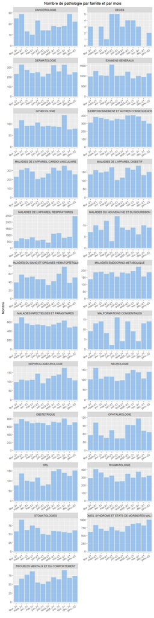

# 12 Actes infirmiers

|  |  | janv. |  |  |  |  |  |  |  |  |  |  |  |  |  |  |  |  |  | Total |
| --- | --- | --- | --- | --- | --- | --- | --- | --- | --- | --- | --- | --- | --- | --- | --- | --- | --- | --- | --- | --- |
|  |  | Maripasoula | Saint Georges | Grand Santi | Apatou | Papaichton | Talhuen | Antecum Pata | Cacao | Regina | Saul | Camopi | Trois Sauts | Kaw | Iracoubo | Javouhey | Awala | Zones hors CDPS | Total |  |
| Accueil - consultation |  | 2165 | 418 | 1294 | 975 | 403 | 484 | 291 | 39 | 1 | 107 | 459 | 343 |  | 334 | 316 | 188 | 4 | 7821 | 7821 |
|  | Examen clinique | 102 | 10 | 4 | 3 | 8 | 45 | 59 | 7 |  | 22 |  | 21 |  |  | 1 |  |  | 282 | 282 |
|  | Prise des constantes(contrôle TA T° poids) | 1842 | 398 | 611 | 966 | 388 | 362 | 221 | 32 | 1 | 85 | 458 | 321 |  | 334 | 310 | 188 | 4 | 6521 | 6521 |
|  | Traduction | 221 | 10 | 679 | 6 | 7 | 77 | 11 |  |  |  | 1 | 1 |  |  | 5 |  |  | 1018 | 1018 |
| Administratif |  | 1891 | 356 | 465 | 66 | 131 | 329 | 216 | 1 |  | 79 | 471 | 199 |  | 378 | 336 | 75 | 4 | 4997 | 4997 |
|  | Autres actes administratifs | 1856 | 349 | 454 | 60 | 131 | 328 | 216 |  |  | 77 | 471 | 194 |  | 378 | 334 | 75 | 4 | 4927 | 4927 |
|  | Menage des chambres et/ou salles (>=30 minutes) | 14 | 2 | 4 |  |  |  |  |  |  |  |  |  |  |  | 1 |  |  | 21 | 21 |
|  | Organisation/préparation départ (pirogue ou avion ou autre) | 1 |  |  | 3 |  | 1 |  |  |  |  |  | 4 |  |  |  |  |  | 9 | 9 |
|  | Papiers transferts (EVASAN) | 20 | 5 | 7 | 3 |  |  |  | 1 |  | 2 |  | 1 |  |  | 1 |  |  | 40 | 40 |
| Examen de laboratoire (sous supervision du médecin) |  | 105 | 7 | 26 |  | 3 |  | 1 |  |  |  |  |  |  |  |  |  |  | 142 | 142 |
|  | Analyse de biologie délocalisée par Horiba | 4 | 4 | 12 |  |  |  |  |  |  |  |  |  |  |  |  |  |  | 20 | 20 |
|  | Analyse de biologie délocalisée par ISTAT (compter 1 par cartouche) | 30 | 2 | 11 |  | 1 |  |  |  |  |  |  |  |  |  |  |  |  | 44 | 44 |
|  | Autre type d''examen de laboratoire | 70 | 1 | 2 |  | 2 |  | 1 |  |  |  |  |  |  |  |  |  |  | 76 | 76 |
|  | Lecture goutte épaisse - frottis | 1 |  |  |  |  |  |  |  |  |  |  |  |  |  |  |  |  | 1 | 1 |
|  | Lecture prélèvement leishmanien |  |  | 1 |  |  |  |  |  |  |  |  |  |  |  |  |  |  | 1 | 1 |
| Injection-Perfusion |  | 321 | 60 | 313 | 94 | 26 | 30 | 13 | 39 |  | 25 | 9 | 32 |  | 5 | 3 | 12 |  | 982 | 982 |
|  | Autres types d''injections | 3 |  | 2 |  |  |  |  |  |  |  |  |  |  |  |  |  |  | 5 | 5 |
|  | Injection Intra dermique pour vaccination | 1 |  | 3 |  | 5 |  |  |  |  |  |  |  |  |  |  |  |  | 9 | 9 |
|  | Injection intramsuculaire pour vaccination | 53 | 1 | 181 | 40 | 5 |  |  | 39 |  | 22 | 1 | 12 |  | 2 |  |  |  | 356 | 356 |
|  | Injection sous cutanée pour vaccination | 6 |  | 71 | 1 | 1 |  |  |  |  |  | 1 |  |  |  | 2 |  |  | 82 | 82 |
|  | Intradermique |  |  | 3 |  |  |  |  |  |  |  |  |  |  |  |  |  |  | 3 | 3 |
|  | Intramusculaire (IM) | 14 | 4 | 13 | 6 | 3 |  |  |  |  |  | 1 | 1 |  | 1 | 1 | 12 |  | 56 | 56 |
|  | Intraveineuse (IV) | 144 | 18 | 10 | 28 | 5 | 16 | 10 |  |  |  | 3 | 13 |  |  |  |  |  | 247 | 247 |
|  | Préparation/pose de perfusion/surveillance < 8 heures | 46 | 6 | 12 | 18 | 1 | 1 | 1 |  |  |  | 3 | 1 |  |  |  |  |  | 89 | 89 |
|  | Préparation/pose de perfusion/surveillance > 8 heures | 44 | 11 | 14 |  |  | 13 | 1 |  |  |  |  | 2 |  |  |  |  |  | 85 | 85 |
|  | Sous-cutanée (S/C) | 10 | 20 | 4 | 1 | 6 |  | 1 |  |  | 3 |  | 3 |  | 2 |  |  |  | 50 | 50 |
| Intervention sur réquisition |  | 1 |  |  |  | 1 |  |  |  |  |  |  |  |  |  |  |  |  | 2 | 2 |
|  | Intervention sur réquisition <15 minutes |  |  |  |  | 1 |  |  |  |  |  |  |  |  |  |  |  |  | 1 | 1 |
|  | Intervention sur réquisition 15 à 30 minutes | 1 |  |  |  |  |  |  |  |  |  |  |  |  |  |  |  |  | 1 | 1 |

[output cut: 52 more lines]

# 13 COVID

## 13.1 Nombre de consultations par CDPS

|  | Janvier |  |  |  |  |  |  |  |  |  |  |  |  |  |  |  |  |  |
| --- | --- | --- | --- | --- | --- | --- | --- | --- | --- | --- | --- | --- | --- | --- | --- | --- | --- | --- |
|  | Maripasoula | Saint Georges | Grand Santi | Apatou | Papaichton | Talhuen | Antecum Pata | Cacao | Regina | Saul | Camopi | Trois Sauts | Kaw | Iracoubo | Javouhey | Awala | Zones hors CDPS | Total |
| Résultat positif | 77 | 133 | 171 | 42 | 58 | 27 | 1 | 27 | 23 |  | 26 | 4 | 2 | 5 | 19 | 37 | 3 | 655 |
| Résultat négatif | 8 | 17 | 136 | 8 | 26 |  |  |  |  |  | 16 |  | 1 |  | 1 | 3 |  | 216 |
| Patient non testé | 1 | 1 | 31 | 6 | 21 | 1 |  |  | 4 |  | 16 |  | 1 | 1 |  | 1 | 1 | 85 |
| En attente de résultat | 14 | 3 | 15 | 1 | 24 | 1 |  |  |  |  |  |  |  |  | 1 | 1 |  | 60 |
| Total | 100 | 154 | 353 | 57 | 129 | 29 | 1 | 27 | 27 |  | 58 | 4 | 4 | 6 | 21 | 42 | 4 | 1016 |

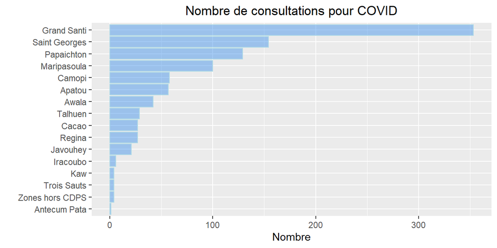

## 13.2 Nombre de patients par mois

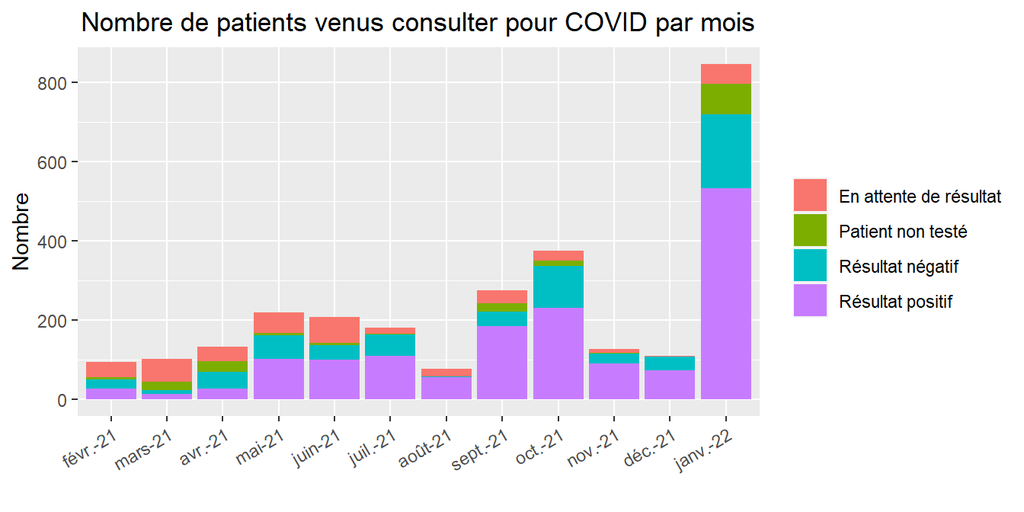

## 13.3 Mise en observation pour COVID

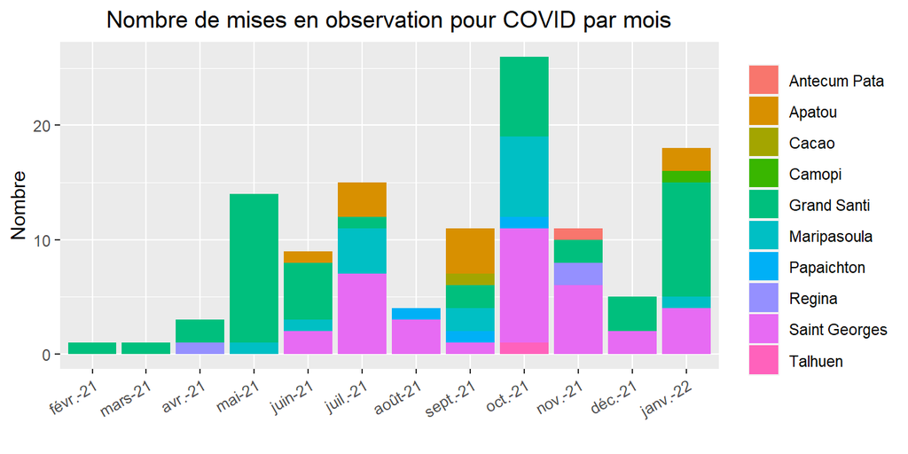

# 14 Lésions auto-infligées

## 14.1 Par type et par CDPS

|  | Janvier |  |  |  |  |  |  |  |  |  |  |  |  |  |  |  |  |  |
| --- | --- | --- | --- | --- | --- | --- | --- | --- | --- | --- | --- | --- | --- | --- | --- | --- | --- | --- |
|  | Maripasoula | Saint Georges | Grand Santi | Apatou | Papaichton | Talhuen | Antecum Pata | Cacao | Regina | Saul | Camopi | Trois Sauts | Kaw | Iracoubo | Javouhey | Awala | Zones hors CDPS | Total |
| Lésion auto-infligée par pendaison- strangulation et suffocation (suicide ou tentative) | 1 | 1 |  |  |  |  |  |  |  |  |  |  |  |  |  |  |  | 2 |
| Auto-intoxication par des médicaments et substances biologiques et exposition à ces produits, autres et sans précision (suicide ou tentative) |  |  | 1 |  |  |  |  |  |  |  |  |  |  |  |  |  |  | 1 |
| Total | 1 | 1 | 1 |  |  |  |  |  |  |  |  |  |  |  |  |  |  | 3 |

## 14.2 Sur les 12 derniers mois

### 14.2.1 par type

|  | 2021 |  |  |  |  |  |  |  |  |  |  | 2022 | Total |
| --- | --- | --- | --- | --- | --- | --- | --- | --- | --- | --- | --- | --- | --- |
|  | févr. | mars | avr. | mai | juin | juil. | août | sept. | oct. | nov. | déc. | janv. |  |
| Lésion auto-infligée par pendaison- strangulation et suffocation (suicide ou tentative) |  |  | 2 |  | 2 |  | 1 |  |  | 1 | 2 | 2 | 10 |
| Auto-intoxication par des produits chimiques et substances novices (suicide ou tentative) |  |  | 2 |  | 1 | 1 |  |  | 1 | 2 |  |  | 7 |
| Auto-intoxication par d'autres substances pharmacologiques agissant sur le système nerveux autonome et exposition à ces produits (suicide ou tentative) |  |  |  |  |  |  |  |  |  | 2 | 1 |  | 3 |
| Auto-intoxication par analgésiques-antipyrétiques et antirhumatismaux non opiacés et exposition à ces produits (suicide ou tentative) |  |  | 1 |  |  | 1 |  |  |  |  |  |  | 2 |
| Auto-intoxication par des medicaments psychotropes (anti-épileptiques/sédatifs/hypnotiques/antiparkinsoniens et psychotropes....) (suicide ou tentative) |  |  |  | 1 |  |  |  |  |  |  | 1 |  | 2 |
| Auto-intoxication par des pesticides et exposition à ces produits (suicide ou tentative) | 1 |  |  |  |  |  |  |  |  |  | 1 |  | 2 |
| Auto-intoxication par des solvants organiques et des hydrocarbures halogénés et leurs émanations et exposition à ces produits (suicide ou tentative) |  |  |  |  |  |  | 2 |  |  |  |  |  | 2 |
| Lésion auto-infligée par utilisation d'objet tranchant (suicide ou tentative) |  |  | 1 | 1 |  |  |  |  |  |  |  |  | 2 |
| Auto-intoxication par des médicaments et substances biologiques et exposition à ces produits, autres et sans précision (suicide ou tentative) |  |  |  |  |  |  |  |  |  |  |  | 1 | 1 |
| Lésion auto-infligée par décharge de fusil, de carabine et d'arme de plus grande taille (suicide ou tentative) |  |  |  |  |  | 1 |  |  |  |  |  |  | 1 |
| Total | 1 |  | 6 | 2 | 3 | 3 | 3 |  | 1 | 5 | 5 | 3 | 32 |

### 14.2.2 par CDPS

|  | 2021 |  |  |  |  |  |  |  |  |  |  | 2022 | Total |
| --- | --- | --- | --- | --- | --- | --- | --- | --- | --- | --- | --- | --- | --- |
|  | févr. | mars | avr. | mai | juin | juil. | août | sept. | oct. | nov. | déc. | janv. |  |
| Maripasoula |  |  |  |  | 1 |  | 1 |  |  | 1 | 3 | 1 | 7 |
| Papaichton | 1 |  | 2 |  | 1 | 1 | 1 |  |  | 1 |  |  | 7 |
| Trois Sauts |  |  | 1 | 1 | 1 |  | 1 |  |  | 1 |  |  | 5 |
| Grand Santi |  |  |  |  |  | 1 |  |  | 1 | 1 |  | 1 | 4 |
| Apatou |  |  |  |  |  | 1 |  |  |  | 1 |  |  | 2 |
| Camopi |  |  | 1 |  |  |  |  |  |  |  | 1 |  | 2 |
| Talhuen |  |  | 1 |  |  |  |  |  |  |  | 1 |  | 2 |
| Iracoubo |  |  |  | 1 |  |  |  |  |  |  |  |  | 1 |
| Regina |  |  | 1 |  |  |  |  |  |  |  |  |  | 1 |
| Saint Georges |  |  |  |  |  |  |  |  |  |  |  | 1 | 1 |
| Total | 1 |  | 6 | 2 | 3 | 3 | 3 |  | 1 | 5 | 5 | 3 | 32 |

### 14.2.3 Par sexe

|  | 2021 |  |  |  |  |  |  |  |  |  |  | 2022 | Total |
| --- | --- | --- | --- | --- | --- | --- | --- | --- | --- | --- | --- | --- | --- |
|  | févr. | mars | avr. | mai | juin | juil. | août | sept. | oct. | nov. | déc. | janv. |  |
| Sexe féminin |  |  | 5 | 2 | 3 | 1 | 2 |  | 1 | 2 | 4 | 2 | 22 |
| Sexe Masculin | 1 |  | 1 |  |  | 2 | 1 |  |  | 3 | 1 | 1 | 10 |
| Total | 1 |  | 6 | 2 | 3 | 3 | 3 |  | 1 | 5 | 5 | 3 | 32 |

### 14.2.4 Par âge

|  | 2021 |  |  |  |  |  |  |  |  |  |  | 2022 | Total |
| --- | --- | --- | --- | --- | --- | --- | --- | --- | --- | --- | --- | --- | --- |
|  | févr. | mars | avr. | mai | juin | juil. | août | sept. | oct. | nov. | déc. | janv. |  |
| <5 ans |  |  |  |  | 1 |  | 1 |  |  |  |  |  | 2 |
| 10-14 ans |  |  | 1 | 1 | 1 |  |  |  |  | 2 |  |  | 5 |
| 15-19 ans |  |  | 2 |  | 1 | 1 | 1 |  | 1 | 1 | 2 | 1 | 10 |
| 20-24 ans |  |  | 1 | 1 |  |  |  |  |  | 1 | 1 | 1 | 5 |
| 25-29 ans |  |  |  |  |  |  |  |  |  | 1 | 1 |  | 2 |
| 30-34 ans |  |  | 1 |  |  | 1 |  |  |  |  | 1 |  | 3 |
| 35-39 ans | 1 |  | 1 |  |  |  |  |  |  |  |  |  | 2 |
| 40-44 ans |  |  |  |  |  | 1 |  |  |  |  |  |  | 1 |
| 45-49 ans |  |  |  |  |  |  |  |  |  |  |  | 1 | 1 |
| 75-79 ans |  |  |  |  |  |  | 1 |  |  |  |  |  | 1 |
| Total | 1 |  | 6 | 2 | 3 | 3 | 3 |  | 1 | 5 | 5 | 3 | 32 |

# 15 Addictologie

|  | 2021 |  |  |  |  |  |  |  |  |  |  | 2022 | Total |
| --- | --- | --- | --- | --- | --- | --- | --- | --- | --- | --- | --- | --- | --- |
|  | févr. | mars | avr. | mai | juin | juil. | août | sept. | oct. | nov. | déc. | janv. |  |
| Alcoolisme chronique | 2 | 4 | 4 | 13 | 11 | 6 | 4 | 5 | 7 | 5 | 7 | 7 | 75 |
| Patient alcoolisé | 1 | 4 | 7 | 8 | 2 | 2 | 1 | 2 | 5 | 9 | 4 | 3 | 48 |
| Troubles mentaux et du comportement liés à la consommation de substances psychoactive |  |  | 3 | 2 | 1 | 1 | 1 | 1 | 1 | 1 | 1 |  | 12 |
| NA |  | 2 | 1 | 1 | 1 |  | 1 |  | 1 |  |  |  | 7 |
| Consommateur chronique de drogues illicites |  | 1 |  | 1 |  |  |  |  |  |  | 1 |  | 3 |
| Patient sous l'emprise de drogues illicites |  |  |  |  |  |  |  |  | 1 |  |  | 2 | 3 |
| Syndrome alcoolisation foetale |  |  | 1 |  |  |  |  | 1 |  |  |  |  | 2 |
| Total | 3 | 11 | 16 | 25 | 15 | 9 | 7 | 9 | 15 | 15 | 13 | 12 | 150 |

|  | Janvier |  |  |  |  |  |  |  |  |  |  |  |  |  |  |  |  |  |
| --- | --- | --- | --- | --- | --- | --- | --- | --- | --- | --- | --- | --- | --- | --- | --- | --- | --- | --- |
|  | Maripasoula | Saint Georges | Grand Santi | Apatou | Papaichton | Talhuen | Antecum Pata | Cacao | Regina | Saul | Camopi | Trois Sauts | Kaw | Iracoubo | Javouhey | Awala | Zones hors CDPS | Total |
| Alcoolisme chronique |  |  | 5 | 1 |  |  |  |  |  |  |  | 1 |  |  |  |  |  | 7 |
| Patient alcoolisé |  | 1 |  | 1 |  |  |  |  |  |  |  | 1 |  |  |  |  |  | 3 |
| Patient sous l'emprise de drogues illicites | 1 | 1 |  |  |  |  |  |  |  |  |  |  |  |  |  |  |  | 2 |
| Total | 1 | 2 | 5 | 2 |  |  |  |  |  |  |  | 2 |  |  |  |  |  | 12 |